# Mapping in R

This document will walk you through creating several maps in R. The components are:

1. Creating a boundary shape for some Basque provinces
2. An interactive map of Basque dative displacement
   - geocoding the data
   - mapping it
3. Creating a topographic map

## Creating boundary shapes

The three traditional regions of the Northern Basque Country (Iparralde) do not correspond to present-day political boundaries (we have the French Revolution to thank for that). This makes mapping of dialect data difficult, since the traditional region boundaries roughly correspond to dialect differences that continue to exist. We can't get a shapefile that contains these boundaries. But we can still map them, with a bit of effort.

We'll use the [Global Administrative Areas](http://gadm.org/) database, which contains shapefiles corresponding to political boundaries for all the world's countries. The French data is [here](http://biogeo.ucdavis.edu/data/gadm2/shp/FRA_adm.zip). This is an ~11MB zip file containing several levels of detail. We want the `FRA_adm5.*` files, containing the most detailed data (the boundaries of individual *comunes*, or towns). The relevant files are also included in this git repository.

We also need to install a few packages. This incantation will install any that are missing on your computer:

```r
install.packages(setdiff(c("maptools","rgeos","ggmap","devtools","mapdata",
                           "xtable"),
                         rownames(installed.packages())))
```

```
## Error: no packages were specified
```

```r
library(maptools)
library(ggplot2)
library(ggmap)
library(devtools)
library(mapdata)
library(xtable)

if (!"rCharts" %in% rownames(installed.packages())) {
    install_github("rCharts", "ramnathv")
}
library(rCharts)
if (!"rMaps" %in% rownames(installed.packages())) {
    install_github("rMaps", "RCura")
}
library(rMaps)
```

```r
## Tell xtable we want html, not latex
options(xtable.type="html", xtable.html.table.attributes="")
```

Now we can read in the file. Even though we only pass the `.shp` file to the `readShapeSpatial` function, the other files (`.dbf`, `.prj`, and `.shx`) will be consulted as well.

```r
france.shapes <- readShapeSpatial("FRA_adm5.shp")
```

This gives a data structure similar to a `data.frame`. The difference is that one of the columns contains not just a single number, string, or boolean, but rather the description of some geometric shape.

We can see what data is actually included in these files (omitting the shapes, which are not very illuminating):

```r
head(france.shapes@data, 3)
```

```
##   OBJECTID ID_0 ISO NAME_0 ID_1           NAME_1 ID_2 NAME_2 ID_3
## 0        1   79 FRA France   11 \xcele-de-France   75  Paris  149
## 1        2   79 FRA France   11 \xcele-de-France   75  Paris  150
## 2        3   79 FRA France   11 \xcele-de-France   75  Paris  151
##                      NAME_3 ID_4                    NAME_4 ID_5
## 0 Paris, 11e arrondissement   25 Paris, 11e arrondissement    1
## 1 Paris, 12e arrondissement   26 Paris, 12e arrondissement    2
## 2  Paris, 12e arronissement   24  Paris, 12e arronissement    3
##                      NAME_5           TYPE_5 ENGTYPE_5 Shape_Leng
## 0 Paris, 11e arrondissement Chef-lieu canton   Commune    0.09200
## 1 Paris, 12e arrondissement Chef-lieu canton   Commune    0.25419
## 2  Paris, 12e arronissement Chef-lieu canton   Commune    0.07699
##   Shape_Area
## 0  0.0004043
## 1  0.0019827
## 2  0.0003666
```

(The `@` is similar to the `$` operator for accessing data frame columns. The exact difference is subtle; for our purpose it suffices to know that `france.shapes@data` picks out the data columns associated with the France shapes, and we could replace `data` with other things to get other aspects of the data, for example the drawing instructions.)

Now we will pick out the `comunes` that belong to one of the historical provinces we are interested in; in this case Lapurdi:

```r
lap.communes <- c("Ahetze", "Ainhoa", "Anglet", "Arbonne", "Arcangues",
                  "Ascain", "Bardos", "Bassussarry", "Bayonne", "Biarritz",
                  "Bidart", "Biriatou", "Bonloc", "Boucau", "Briscous",
                  "Cambo-les-Bains", "Ciboure", "Espelette", "Gu\xe9thary",
                  "Guiche", "Halsou", "Hasparren", "Hendaye", "Itxassou",
                  "Jatxou", "Lahonce", "Larressore", "Louhossoa", "Macaye",
                  "Mendionde", "Mouguerre", "Saint-Jean-de-Luz",
                  "Saint-P\xe9e-sur-Nivelle", "Saint-Pierre-d'Irube",
                  "Sare", "Soura\xefde", "Urcuit", "Urrugne", "Urt", "Ustaritz",
                  "Villefranque")
lap.polygons <- france.shapes[france.shapes@data$NAME_5 %in% lap.communes &
                              as.integer(france.shapes@data$ID_5) != 28077,]
```

The first command just creates a list of `comunes` in Lapurdi (from the Municipalities in Labourd box at the bottom of the [Wikipedia page](https://en.wikipedia.org/wiki/Labourd).) I had to make sure to spell the names the same way that they are spelled in the dataset (basically, using French rather than Basque names). There are some funny codes in the strings; for example the French don't have a town named “Gu\xe9thary”. These are character escape codes. The dataset from GADM uses [ISO Latin-1](https://en.wikipedia.org/wiki/ISO/IEC_8859-1) encoding, which is a way of numerically representing letters in computer memory. Most computers today use Unicode. The letter “é”, for example, is represented by the number 233 in Latin-1, but as the two-number sequence (195, 169) in UTF-8 (which is the most common dialect of Unicode). To avoid confusion, we enter the Latin-1 numeric representation directly into R. “\xe9” is the number 233 in [hexadecimal, or base-16](https://en.wikipedia.org/wiki/Hexadecimal).

Then, we take a subset of the rows in our data. This looks complicated, but remember, subsetting a data frame in R is just `var[rows,cols]`. We want all columns, so we leave the columns selector blank (the second line of the command ends with `,]`). The rows we select are just the ones where the name of the `comune` (`france.shapes@data$NAME_5`) is in our list of Labourdin `comunes`.

There's one additional complication: there is more than one “Villefranque” in France:

```r
france.shapes[france.shapes@data$NAME_5 == "Villefranque",]@data
```

```
##       OBJECTID ID_0 ISO NAME_0 ID_1              NAME_1 ID_2
## 25335    25336   79 FRA France   72           Aquitaine   64
## 28076    28077   79 FRA France   73 Midi-Pyr\xe9n\xe9es   65
##                           NAME_2 ID_3  NAME_3 ID_4
## 25335 Pyr\xe9n\xe9es-Atlantiques   30 Bayonne   52
## 28076      Hautes-Pyr\xe9n\xe9es  242  Tarbes    9
##                           NAME_4  ID_5       NAME_5         TYPE_5
## 25335       Saint-Pierre-d'Irube 25336 Villefranque Commune simple
## 28076 Castelnau-Rivi\xe8re-Basse 28077 Villefranque Commune simple
##       ENGTYPE_5 Shape_Leng Shape_Area
## 25335   Commune    0.20895  0.0018689
## 28076   Commune    0.09218  0.0003883
```

So we use the ID number to de-select the wrong Villefranque (as determined by latitude/longitide).

Here's what we have so far:

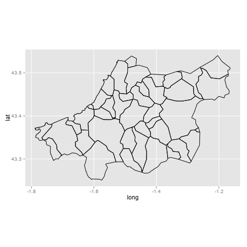

```r
ggplot(fortify(lap.polygons), aes(x = long, y = lat, group = group)) +
  geom_polygon(fill = NA, color = "black") +
  coord_map()
```

We want to get rid of the interior lines, and only plot the outer boundaries of the region:

```r
lap.polygon <- unionSpatialPolygons(lap.polygons,
                                    rep(1, length(lap.polygons)))
```

The second argument is just a list of 1s; it tells R to assign all the polygons in the input to the same output polygon. And here we have it:

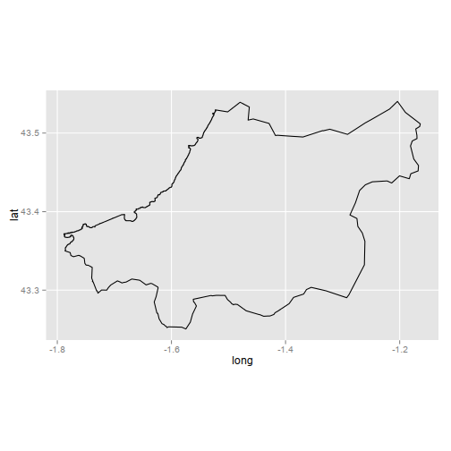

```r
ggplot(fortify(lap.polygon), aes(x = long, y = lat, group = group)) +
  geom_polygon(fill = NA, color = "black") +
  coord_map()
```

We can compare the image to [Wikipedia](https://upload.wikimedia.org/wikipedia/commons/2/20/Labort-Pirineos_Atl%C3%A1nticos.svg), and see we've gotten it right.

## Basque dative displacement

Dative displacement (DD) is a morphological operation in Basque. For many details, consult [this article by Rezac & Fernández](http://www.umr7023.cnrs.fr/sites/sfl/IMG/pdf/DL3-2-2.pdf). For our purposes, it suffices to know that it's an innovation that has been spreading from several loci over the past ~150 years. We'll make a map of this data.

Let's read that data:

```r
dd <- read.csv("dd.csv", colClasses = c("character", "logical"))
kable(head(dd))
```

| name | dd |
| --- | --- |
| Abaurrea Alta | FALSE |
| Ahetze | TRUE |
| Aïnhoa | TRUE |
| Albiasu | FALSE |
| Albóniga | FALSE |
| Alcayaga | FALSE |

This is a very simple data frame, with just a town name and an indication of whether the local dialect has DD (summarized by me from the [MVAV atlas](http://euskaltzaindia.net/mvav)). The first step is to geocode the data. This is very simple thanks to the `ggmap` package (requires an internet connection and ~5 minutes):

```r
library(ggmap)
geocoded <- geocode(dd$name, messaging = FALSE)
dd.geo <- cbind(dd, geocoded)
save(dd.geo, file = "dd-geo.Rdata")
```

We don't actually evaluate the above code when running this document. Instead we'll load the result I've saved, and look at places where the geocoding failed:

```r
load("dd-geo.Rdata")
xtable(subset(dd.geo, is.na(lon)))
```

|  | name | dd | lon | lat |
| --- | --- | --- | --- | --- |
| 5 | Albóniga | FALSE |  |  |
| 12 | Anguiozar | FALSE |  |  |
| 29 | Arráyoz | FALSE |  |  |
| 51 | Baztango bordak | FALSE |  |  |
| 73 | Echagüen | FALSE |  |  |
| 93 | Eugui | FALSE |  |  |
| 107 | Gurbízar | FALSE |  |  |
| 140 | Leránoz | FALSE |  |  |
| 152 | Mezquíriz | FALSE |  |  |
| 191 | Urrizola-Hego | FALSE |  |  |
| 196 | Usechi | FALSE |  |  |

That's 11 failures in 215 rows. Not bad. There are also 48 locations that got coded incorrectly. This figure is more disappointing; probably we should have given more specific locations (by adding a province or country name to the town). For now, we'll just filter them out by restricting the data to the latitude and longitude we are interested in:

```r
dd.geo <- subset(dd.geo, !is.na(lat) & dd.geo$lat < 43.46 & dd.geo$lat > 42.66)
```

For semi-manual geocoding, a good source of place names with latitude and longitude information is [the US military](http://earth-info.nga.mil/gns/html/namefiles.htm).

Now let's make an interactive map.

```r
map <- Leaflet$new()
map$setView(c(43, -1.5), zoom = 9)
map$tileLayer(provider = 'Stamen.TonerLite')

## There's no way to add points in bulk, so we'll loop through the data
for (i in 1:nrow(dd.geo)) {
    map$circle(c(dd.geo[i,"lat"], dd.geo[i,"lon"]), radius = 500,
               setStyle = list(
                stroke = FALSE, fill = TRUE,
                fillColor = ifelse(dd.geo[i,"dd"], "red", "blue"),
                fillOpacity = 1),
                bindPopup = dd.geo[i,"name"])
}

map$legend(position = "topright",
           colors = c("#f00", "#00f"),
           labels = c("DD", "no DD"))

map$print("dd.map", include_assets = TRUE)
```

[interactive chart not shown]

## Topographic map

Let's make a topographic map of this data. We'll use files from the US Geological Survey, which (nonetheless) cover the whole world. We can download the files from this FTP link. The files are divided into pieces by latitude and longitude; this handy file shows which files correspond to which tiles.

We need to get the values out of their native grid format and into the expected (lat, long, measurement) format for ggplot. Here's code to do this (we won't actually run it becuase it takes several minutes and lots of memory):

```r
library(raster)
library(rgdal)

topo <- raster("W020N90.DEM")
topo.df <- rasterToPoints(topo)
topo.df <- subset(as.data.frame(topo.df),
                  y > 42.5 & y < 43.5 & x < -1 & x > -3)
save(topo.df, file = "topo-df.Rdata")
```

```r
load("topo-df.Rdata")
boundaries <- map_data("worldHires", xlim = c(-2,-1.25), ylim = c(43,43.5))
```

Now we can map:

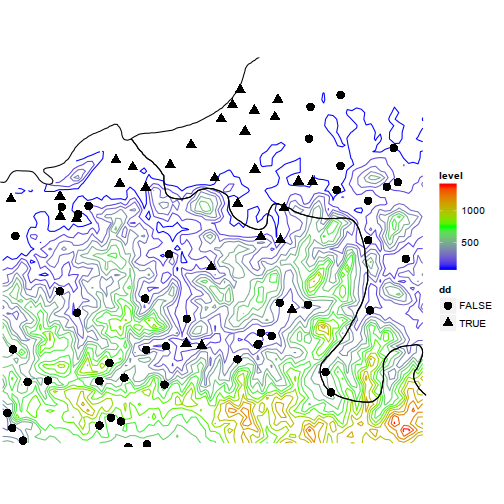

```r
ggplot(aes(x = x, y = y), data = subset(topo.df,
                                        x > -2 & x < -1.25 &
                                        y > 43 & y < 43.5)) +
    geom_contour(aes(color = ..level.., z = W020N90), binwidth = 100) +
    coord_map(xlim = c(-2,-1.25), ylim = c(43,43.5)) +
    scale_color_gradientn(colours = c("blue","green","red")) +
    geom_point(aes(x = lon, y = lat, shape = dd), data = dd.geo, size = 4) +
    theme_nothing(legend = TRUE) +
    geom_path(aes(x = long, y = lat, group = group), data = boundaries)
```

`..level..` is a “magic” variable that sets the colors of the contour lines to the height calculated by ggplot. **CAVEAT**: the color palette used here is pretty awful from a perceptual standpoint; if you were serious about this map you'd want to look for a better one. We cannot use color to distinguish the points (as ggplot allows only one color per plot).